# Financial Fraud Detection Report

2025-09-08

## Objektive

This model helps identify potential fraud cases by analyzing unusual trends in financial transactions.

## Scope

It provides a powerful solution for detecting fraud activities at an early stage in sectors with high transaction volumes such as banking, e-commerce, and insurance.

## Value Added

This approach minimizes financial losses for organizations while enhancing customer trust and operational sustainability.

## Scenario Modeling

The technical analysis and modeling steps have been supported by real-life scenarios to improve understanding. These scenarios aim to demonstrate how the methods used and the findings obtained reflect business processes. Therefore, the report is designed to add value not only to technical experts but also to business units.

In this context, let’s consider an insurance company. The company faces thousands of different transactions every day: claims, premium payments, policy cancellations, and more. In this report, we will illustrate how the analyses make sense for the insurance company.

## Loading Libraries

In the first step, we import the necessary Python libraries.

**`pandas`** will be used for data processing, **`numpy`** for numerical operations, and **`matplotlib`** and **`seaborn`** for visualization.

```python
import pandas as pd
import numpy as np
import matplotlib.pyplot as plt
import seaborn as sns
```

## Loading the Dataset

Here, we load our dataset in CSV format using the **pandas.read_csv`** function. Then, we use **`df.shape`** to see how many rows and columns are in the dataset.

```python
df = pd.read_csv("AIML Dataset.csv")
df.shape
```

```
## (6362620, 11)
```

## Replace

The code, graphs, and data types have been organized for a more user-friendly experience.

```python
df["type"] = df["type"].replace({
    "CASH_OUT": "Cash Out",
    "PAYMENT": "Payment",
    "TRANSFER": "Transfer",
    "DEBIT": "Debit",
    "CASH_IN": "Cash In"
})
```

## Looking at the First Rows

We use the **`head()`** function to display the first 5 rows of the dataset. This helps us quickly understand the variable names and the structure of the data.

```python
df.head()
```

```
##    step      type    amount  ... newbalanceDest  isFraud  isFlaggedFraud
## 0     1   Payment   9839.64  ...            0.0        0               0
## 1     1   Payment   1864.28  ...            0.0        0               0
## 2     1  Transfer    181.00  ...            0.0        1               0
## 3     1  Cash Out    181.00  ...            0.0        1               0
## 4     1   Payment  11668.14  ...            0.0        0               0
##
## [5 rows x 11 columns]
```

## Basic Information

We use the **`info()`** function to view the column types, check for missing values, and see the memory usage.

```python
df.info()
```

```
## <class 'pandas.core.frame.DataFrame'>
## RangeIndex: 6362620 entries, 0 to 6362619
## Data columns (total 11 columns):
##  #   Column          Dtype
## ---  ------          -----
##  0   step            int64
##  1   type            object
##  2   amount          float64
##  3   nameOrig        object
##  4   oldbalanceOrg   float64
##  5   newbalanceOrig  float64
##  6   nameDest        object
##  7   oldbalanceDest  float64
##  8   newbalanceDest  float64
##  9   isFraud         int64
##  10  isFlaggedFraud  int64
## dtypes: float64(5), int64(3), object(3)
## memory usage: 534.0+ MB
```

## Statistical Summary

We use the **`describe()`** function to display the basic statistics of the numerical variables (mean, standard deviation, min, max, and quartiles).

```python
df.describe()
```

```
##                step        amount  ...       isFraud  isFlaggedFraud
## count  6.362620e+06  6.362620e+06  ...  6.362620e+06    6.362620e+06
## mean   2.433972e+02  1.798619e+05  ...  1.290820e-03    2.514687e-06
## std    1.423320e+02  6.038582e+05  ...  3.590480e-02    1.585775e-03
## min    1.000000e+00  0.000000e+00  ...  0.000000e+00    0.000000e+00
## 25%    1.560000e+02  1.338957e+04  ...  0.000000e+00    0.000000e+00
## 50%    2.390000e+02  7.487194e+04  ...  0.000000e+00    0.000000e+00
## 75%    3.350000e+02  2.087215e+05  ...  0.000000e+00    0.000000e+00
## max    7.430000e+02  9.244552e+07  ...  1.000000e+00    1.000000e+00
##
## [8 rows x 8 columns]
```

## Missing Value Check

We use **`isnull().sum()`** to check how many missing values there are in each column. This is the first step in data cleaning.

```python
df.isnull().sum()
```

```
## step              0
## type              0
## amount            0
## nameOrig          0
## oldbalanceOrg     0
## newbalanceOrig    0
## nameDest          0
## oldbalanceDest    0
## newbalanceDest    0
## isFraud           0
## isFlaggedFraud    0
## dtype: int64
```

## Identifying Columns

We use **`df.columns`** to check the column names.

```python
df.columns
```

```
## Index(['step', 'type', 'amount', 'nameOrig', 'oldbalanceOrg', 'newbalanceOrig',
##        'nameDest', 'oldbalanceDest', 'newbalanceDest', 'isFraud',
##        'isFlaggedFraud'],
##       dtype='object')
```

## Counting Fraud Cases

The **`value_counts()`** function calculates the frequency distribution of the values in the isFraud column. Here, 0 represents non-fraudulent transactions, and 1 represents fraudulent transactions. The number of fraud cases reveals the extent of the risk the organization is exposed to. The frequency of these cases helps identify areas with higher levels of fraudulent activity, assisting in prioritizing actions.

For example, if the system marks 20 out of 1000 requests as fraudulent, the company can understand the extent of its exposure to risk.

```python
df["isFraud"].value_counts()
```

```
## isFraud
## 0    6354407
## 1       8213
## Name: count, dtype: int64
```

## Counting Flagged Frauds

The **`value_counts()`** function displays the distribution of values in the isFlaggedFraud column. This column shows the transactions automatically flagged as potential fraud by the system. The number of flagged frauds indicates which transactions the model considers suspicious. This count is a key metric for balancing the model’s fraud detection capacity (recall) with its tendency to produce false positives (false positive rate).

For example, if the same person reports multiple accidents in a short period, the model will flag this transaction as “under review.”

```python
df["isFlaggedFraud"].value_counts()
```

```
## isFlaggedFraud
## 0    6362604
## 1         16
## Name: count, dtype: int64
```

## Dataset Size

The **shape** attribute displays the dimensions of the dataset. The output returns the values in the form of (rows, columns). This shows the total number of transactions and the number of columns (features).

```python
df.shape
```

```
## (6362620, 11)
```

## Calculating the Fraud Rate

df[“isFraud”].value_counts()[1] → the number of fraud transactions (those with a value of 1),

df.shape[0] → the total number of transactions,

The ratio is calculated by dividing these values,

round(…, 2) rounds the result to two decimal places as a percentage.

```python
round((df["isFraud"].value_counts()[1] / df.shape[0]) * 100,2)
```

```
## np.float64(0.13)
```

## Transaction Types Overview

This code visualizes the frequency of transaction **`types`** in the type column using a **`bar plot`**. The X-axis represents the transaction types, while the Y-axis shows how many times each type has occurred. This allows for easy analysis of which transaction types are used more frequently, thereby highlighting which behaviors are more dominant in the dataset.

Continuing with our example, understanding whether damage claims or premium refunds occur more frequently helps the company identify which area is experiencing the most workload.

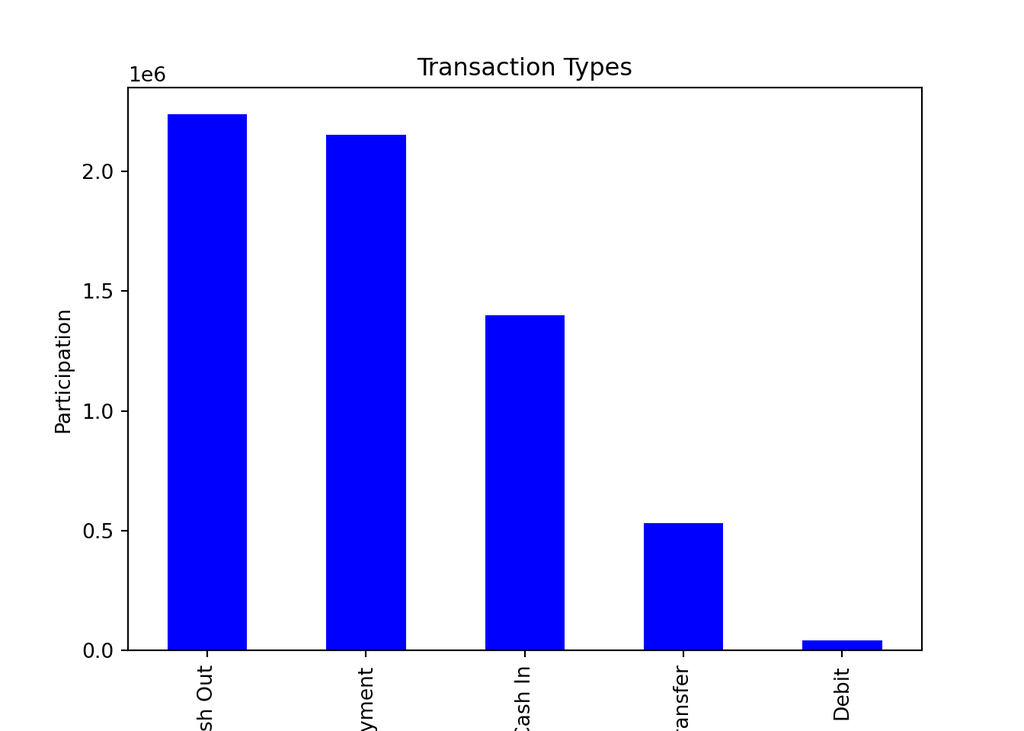

```python
df["type"].value_counts().plot(kind="bar", title="Transaction Types", color = "blue")
plt.xlabel("Transaction Types", labelpad=20)
plt.ylabel("Participation")
plt.show()
```

## Fraud Rate by Transaction Type

First, the transactions are grouped by type using **`groupby("type")`**. Then, the fraud rate (the mean of **`isFraud`**) is calculated for each type and sorted in descending order. The results are visualized using a bar plot.

This approach helps identify which transaction types carry a higher fraud risk, contributing to risk-focused evaluations and the development of preventive strategies.

For example, if the fraud rate for vehicle accident claims is 5% and for health insurance claims is 15%, this clearly indicates which transaction type poses a higher risk.

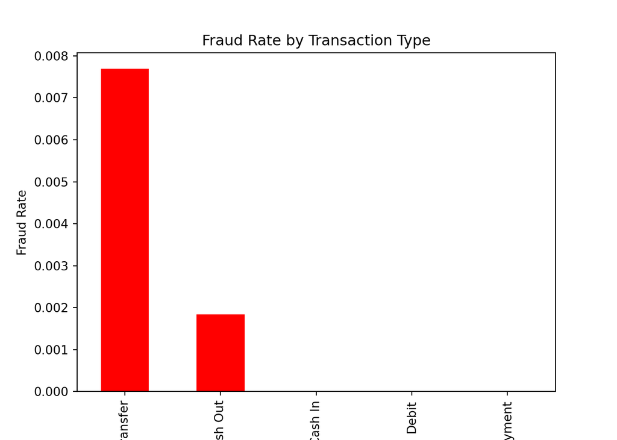

```python
fraud_by_type = df.groupby("type")["isFraud"].mean().sort_values(ascending=False)
fraud_by_type.plot(kind="bar", title="Fraud Rate by Transaction Type", color="Red")
plt.xlabel("Transaction Types", labelpad=20)
plt.ylabel("Fraud Rate")
plt.show()
```

## Statistical Summary of Transaction Amounts

The **`describe()`** function is used to calculate the statistical summary (minimum, maximum, mean, quartiles, etc.) for the **amount`** column. The values are converted to integers using **astype(int)`**. By extracting the general profile of the transaction amounts, it becomes easier to detect unusual activities.

```python
df["amount"].describe().astype(int)
```

```
## count     6362620
## mean       179861
## std        603858
## min             0
## 25%         13389
## 50%         74871
## 75%        208721
## max      92445516
## Name: amount, dtype: int64
```

## Transaction Amounts on a Logarithmic Scale

The **`np.log1p()`** function transforms transaction amounts to a logarithmic scale. A histogram is plotted using **`histplot`** to visualize the distribution. The **`kde=True`** parameter adds a density curve, allowing for a clearer view of the distribution. This method, especially by reducing the effect of outliers, enables a more balanced distribution analysis.

Let’s consider damage claims in an insurance company. Most customers submit claims for small amounts (e.g., a few thousand units). However, rarely, there may be claims with very high amounts (e.g., hundreds of thousands). When these claims are displayed on a normal scale, the large amounts overshadow the small ones, making it difficult to see the behavior of the majority. This is where the logarithmic scale comes into play. By balancing the difference between small and large claims, it ensures that both normal and extraordinary claims are visible in the same graph in a fairer way. In this way, the company can more easily analyze both routine daily claims and the risky, unusually high claims.

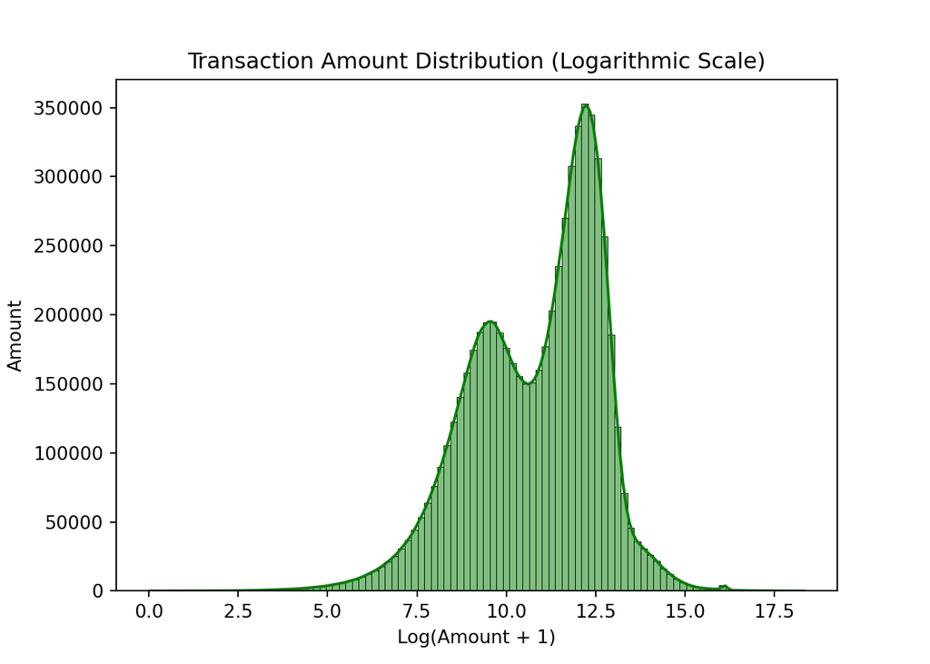

```python
sns.histplot(np.log1p(df["amount"]), bins=100, kde=True, color="green")
plt.title("Transaction Amount Distribution (Logarithmic Scale)")
plt.xlabel("Log(Amount + 1)")
plt.ylabel("Amount")
plt.show()
```

## Box Plot for Transactions Below 50K

This code filters transactions below 50,000 **`(amount < 50000)`** and creates a box plot based on the **`isFraud`** status. The distribution of transaction amounts for fraudulent and non-fraudulent transactions is visualized for comparison. This approach provides an important visualization technique for analyzing the trend of fraud cases in terms of transaction amounts.

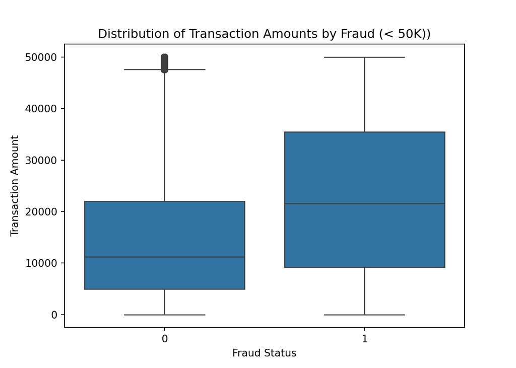

```python
sns.boxplot(data= df[df["amount"] < 50000], x = "isFraud", y = "amount")
plt.title("Distribution of Transaction Amounts by Fraud (< 50K))")
plt.ylabel("Transaction Amount")
plt.xlabel("Fraud Status")
plt.show()
```

## Calculating Balance Differences

Two new variables have been created in the analysis: **`balanceDiffOrig`**: the difference between the sender’s balance before and after the transaction, **`balanceDiffDest`**: the difference between the receiver’s balance before and after the transaction. *These columns have been added to identify potential balance inconsistencies during the transaction and to analyze anomalous behaviors more effectively.*

For example, if the account movements of both the insured and the company are inconsistent after a damage payment (i.e., the amount leaving the company and the amount received by the customer are not the same), this indicates a potential fraud risk.

```python
df["balanceDiffOrig"] = df["oldbalanceOrg"] - df["newbalanceOrig"]
df["balanceDiffDest"] = df["newbalanceDest"] - df["oldbalanceDest"]
```

## Counting Negative Balance Differences

This expression returns the count of values less than 0 in the balanceDiffOrig column. It counts situations where the sender’s balance has **`irrationally increased`** after the transaction.

For example, if an insured individual appears to receive a payment after an accident but actually has extra money in their account, this could indicate either a system error or a malicious attempt.

```python
(df["balanceDiffOrig"] < 0).sum()
```

```
## np.int64(1399253)
```

## Negative Values in Destination Balance Difference

This expression returns the total count of values less than zero in the **`balanceDiffDest`** column. It counts situations where the receiver’s balance has irrationally decreased after the transaction. This analysis helps identify potential fraud by counting unreasonable balance decreases.

```python
(df["balanceDiffDest"] < 0).sum()
```

```
## np.int64(1238864)
```

## Displaying the First 2 Rows

The **`head(2)`** function lists the first two rows of the dataset. This is used to quickly inspect the data structure.

```python
df.head(2)
```

```
##    step     type   amount  ... isFlaggedFraud  balanceDiffOrig  balanceDiffDest
## 0     1  Payment  9839.64  ...              0          9839.64              0.0
## 1     1  Payment  1864.28  ...              0          1864.28              0.0
##
## [2 rows x 13 columns]
```

## Fraud Distribution Over Time

The **`step`** column contains the time information. Fraudulent transactions are filtered, and the number of fraud cases per step is calculated and visualized using a line chart. By tracking the distribution of fraud cases over time, we aim to identify periods when the risk increased and plan preventive actions accordingly.

For example, let’s consider a scenario in an insurance company where damage claims suddenly increase on certain days. These fluctuations could indicate organized fraud attempts or risks that are more concentrated during specific periods.

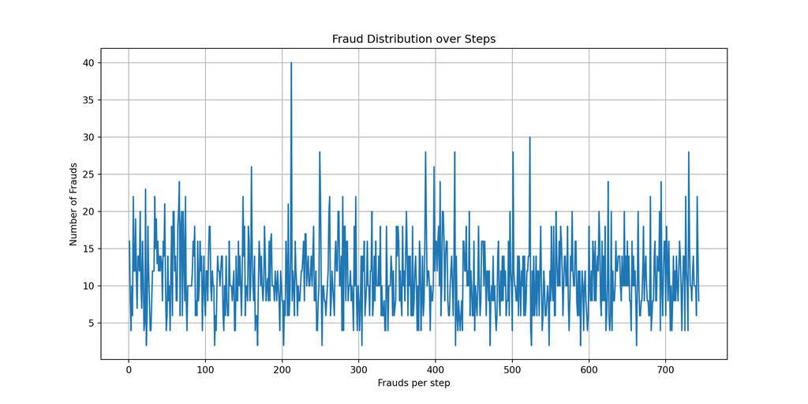

```python
fraud_per_step = df[df["isFraud"] == 1]["step"].value_counts().sort_index()
plt.figure(figsize=(12,6))
plt.plot(fraud_per_step.index , fraud_per_step.values, label="Frauds per Step")
plt.xlabel("Frauds per step")
plt.ylabel("Number of Frauds")
plt.title("Fraud Distribution over Steps")
plt.grid(True)
plt.show()
```

## Dropping the step Column

The **`step`** column is completely removed from the dataset. With **`inplace=True`**, the change is permanent.

```python
df.drop(columns="step",inplace=True)
```

## Top 10 Senders

The top 10 users with the most transactions in the **`nameOrig`** column are listed. Identifying the most frequent transaction senders helps in detecting unusual transaction volumes, enabling the early detection of potential risks.

For example, in an insurance company, some customers may make significantly more transactions than others. If a user submits hundreds of requests in a short period, this could indicate an unusual situation.

```python
top_senders = df["nameOrig"].value_counts().head(10)
```

## Displaying the Sender List

The output of **`top_senders`**, calculated in the previous line, is displayed.

```python
top_senders
```

```
## nameOrig
## C1677795071    3
## C1999539787    3
## C724452879     3
## C1976208114    3
## C400299098     3
## C1784010646    3
## C1530544995    3
## C1065307291    3
## C545315117     3
## C1902386530    3
## Name: count, dtype: int64
```

## Top 10 Receivers

The top 10 users with the most transactions in the **`nameDest`** column are listed.

In an insurance company, it could be observed that some users receive much more payment than others. For example, if the same person is consistently receiving payments from different policies, this could be an unusual and suspicious situation.

```python
top_receivers = df["nameDest"].value_counts().head(10)
```

## Displaying the Receiver List

The output of **`top_receivers`**, calculated in the previous line, is displayed.

```python
top_receivers
```

```
## nameDest
## C1286084959    113
## C985934102     109
## C665576141     105
## C2083562754    102
## C248609774     101
## C1590550415    101
## C1789550256     99
## C451111351      99
## C1360767589     98
## C1023714065     97
## Name: count, dtype: int64
```

## Top Senders Involved in Fraud

Only transactions where **`isFraud=1`** are filtered, and the top 10 senders with the most fraudulent transactions are listed.

In an insurance company, some individuals may attempt fraud much more frequently than others. For example, if a user repeatedly submits fraudulent damage claims on different dates, this person will stand out in the system.”

```python
fraud_users = df[df["isFraud"]== 1]["nameOrig"].value_counts().head(10)
```

## Fraudulent Sender List

The output of **`fraud_users`**, obtained in the previous line, is displayed

```python
fraud_users
```

```
## nameOrig
## C1305486145    1
## C840083671     1
## C1420196421    1
## C2101527076    1
## C137533655     1
## C1118430673    1
## C749981943     1
## C1334405552    1
## C467632528     1
## C1364127192    1
## Name: count, dtype: int64
```

## Selecting Relevant Types for Fraud

**`Transfer`** and **`Cash Out`** transactions are filtered, and a new DataFrame *(fraud_types)* is created. By filtering for transfer and cash-out transactions, we can focus on a more in-depth analysis of the transaction types where fraud is most commonly observed.

```python
fraud_types = df[df["type"].isin(["Transfer","Cash Out"])]
```

## First Rows of Fraud Types

The first 5 rows of the **`fraud_types`** DataFrame are displayed.

```python
fraud_types.head()
```

```
##         type     amount  ... balanceDiffOrig  balanceDiffDest
## 2   Transfer     181.00  ...           181.0             0.00
## 3   Cash Out     181.00  ...           181.0        -21182.00
## 15  Cash Out  229133.94  ...         15325.0         46430.44
## 19  Transfer  215310.30  ...           705.0        -22425.00
## 24  Transfer  311685.89  ...         10835.0       2712905.89
##
## [5 rows x 12 columns]
```

## Frequencies of Fraud Types

The most frequently occurring type in the filtered data is calculated.

```python
fraud_types["type"].value_counts()
```

```
## type
## Cash Out    2237500
## Transfer     532909
## Name: count, dtype: int64
```

## Fraud Types Column Names

All column names in the **`fraud_types`** DataFrame are printed..

```python
print(fraud_types.columns)
```

```
## Index(['type', 'amount', 'nameOrig', 'oldbalanceOrg', 'newbalanceOrig',
##        'nameDest', 'oldbalanceDest', 'newbalanceDest', 'isFraud',
##        'isFlaggedFraud', 'balanceDiffOrig', 'balanceDiffDest'],
##       dtype='object')
```

## Fraud Distribution by Type

The **`countplot`** is used to visualize the comparison of fraud and non-fraud cases in *Transfer* and *Cash Out* transactions.

```python
sns.countplot(data=fraud_types, x="type", hue="isFraud", palette="Set1",)
plt.xticks(rotation=90)
```

```
## ([0, 1], [Text(0, 0, 'Transfer'), Text(1, 0, 'Cash Out')])
```

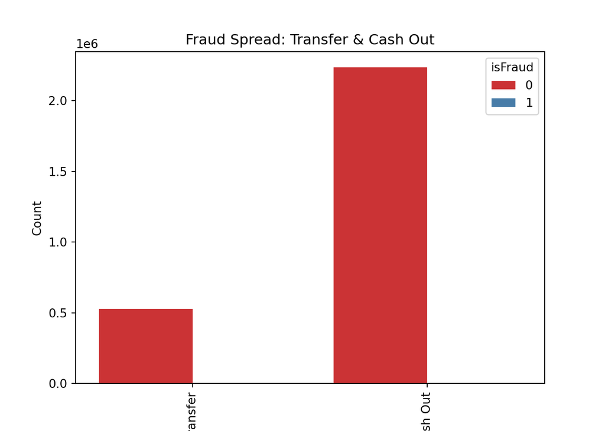

```python
plt.title("Fraud Spread: Transfer & Cash Out",)
plt.xlabel("Types", labelpad=25)
plt.ylabel("Count", )
plt.show()
```

## Calculating the Correlation Matrix

The *correlation coefficients* between the selected numerical columns are calculated.

```python
corr = df[["amount","oldbalanceOrg","newbalanceOrig","oldbalanceDest", "newbalanceDest","isFraud"]].corr()
```

## Correlation Matrix Output

The correlation coefficients table is displayed.

```python
corr
```

```
##                   amount  oldbalanceOrg  ...  newbalanceDest   isFraud
## amount          1.000000      -0.002762  ...        0.459304  0.076688
## oldbalanceOrg  -0.002762       1.000000  ...        0.042029  0.010154
## newbalanceOrig -0.007861       0.998803  ...        0.041837 -0.008148
## oldbalanceDest  0.294137       0.066243  ...        0.976569 -0.005885
## newbalanceDest  0.459304       0.042029  ...        1.000000  0.000535
## isFraud         0.076688       0.010154  ...        0.000535  1.000000
##
## [6 rows x 6 columns]
```

## Visualization of the Correlation Matrix

For example, if a strong relationship is found between high transaction amounts and balance inconsistencies, this could be an important indicator for suspicious transactions.

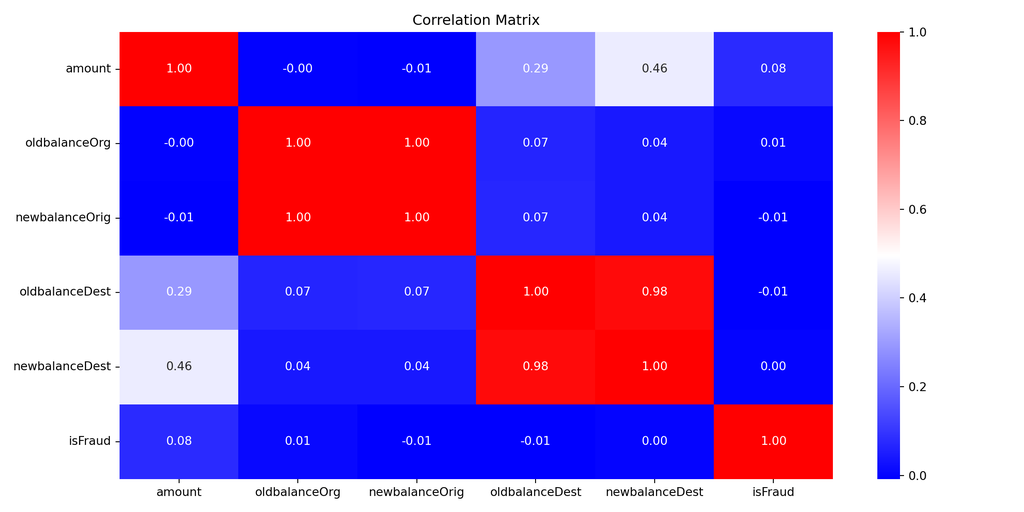

```python
plt.figure(figsize=(12,6))
sns.heatmap(corr, annot=True, cmap= "bwr", fmt =".2f")
plt.title("Correlation Matrix", )
plt.tight_layout()
plt.show()
```

## Filtering Suspicious Transfer Transactions

Transactions where the sender’s balance is greater than 0, but the balance becomes 0 after the transaction, and the type is either Transfer or Cash Out, are selected. This filtering helps identify transactions with unreasonable balance changes and high fraud risk, allowing for a more detailed investigation.

```python
zero_after_transfer = df[
(df["oldbalanceOrg"]>0) &
(df["newbalanceOrig"] == 0 ) &
(df["type"].isin(["Transfer","Cash Out"]))
]
```

## Number of Suspicious Transactions

The number of filtered transactions is calculated.

```python
len(zero_after_transfer)
```

```
## 1188074
```

## First 5 Rows of Suspicious Transactions

The first 5 rows of suspicious transactions are displayed.

```python
zero_after_transfer.head(5)
```

```
##         type     amount  ... balanceDiffOrig  balanceDiffDest
## 2   Transfer     181.00  ...           181.0             0.00
## 3   Cash Out     181.00  ...           181.0        -21182.00
## 15  Cash Out  229133.94  ...         15325.0         46430.44
## 19  Transfer  215310.30  ...           705.0        -22425.00
## 24  Transfer  311685.89  ...         10835.0       2712905.89
##
## [5 rows x 12 columns]
```

## Frequency of Fraud Cases

The count of fraudulent and non-fraudulent transactions is listed.

```python
df["isFraud"].value_counts()
```

```
## isFraud
## 0    6354407
## 1       8213
## Name: count, dtype: int64
```

## Importing the Required Sklearn Libraries

The necessary functions and classes for data preprocessing, modeling, and evaluation are imported.

```python
from sklearn.model_selection import train_test_split
from sklearn.preprocessing import StandardScaler
from sklearn.linear_model import LogisticRegression
from sklearn.metrics import classification_report , confusion_matrix
from sklearn.pipeline import  Pipeline
from sklearn.compose import ColumnTransformer
from sklearn.preprocessing import OneHotEncoder
from sklearn.ensemble import RandomForestRegressor
```

## Dropping Unnecessary Columns for Modeling

The **`nameOrig`**, **`nameDest`**, and **`isFlaggedFraud`** columns are removed from the model. Only meaningful and explanatory variables are left in the model. This ensures that the model produces more accurate, efficient, and generalizable results.

```python
df_model = df.drop(["nameOrig","nameDest", "isFlaggedFraud"], axis= 1 )
```

## First Rows of the Model Dataset

The first rows of the prepared **`df_model`** dataset are displayed.

```python
df_model.head()
```

```
##        type    amount  oldbalanceOrg  ...  isFraud  balanceDiffOrig  balanceDiffDest
## 0   Payment   9839.64       170136.0  ...        0          9839.64              0.0
## 1   Payment   1864.28        21249.0  ...        0          1864.28              0.0
## 2  Transfer    181.00          181.0  ...        1           181.00              0.0
## 3  Cash Out    181.00          181.0  ...        1           181.00         -21182.0
## 4   Payment  11668.14        41554.0  ...        0         11668.14              0.0
##
## [5 rows x 9 columns]
```

## Separation of Variables by Type

Categorical and numerical variables are defined in separate lists. Defining categorical and numerical variables in separate lists ensures that appropriate analysis methods and modeling techniques are applied to each variable. This improves the model’s performance and interpretability.

```python
categorical = ["type"]
numeric = ["amount", "oldbalanceOrg", "newbalanceOrig","oldbalanceDest","newbalanceDest"]
```

## Separation of Dependent and Independent Variables

The target variable **(y)*** is **isFraud**, and the independent variables **(X)** are the other columns. This is a fundamental step for the model to learn to predict fraud.

```python
y = df_model["isFraud"]
X = df_model.drop("isFraud", axis= 1 )
```

## Splitting the Data into Training and Testing Sets

The dataset is split into **70%** training and **30%** testing. The **stratify** parameter ensures that class imbalance is preserved..

```python
X_train, X_test, y_train , y_test = train_test_split(X,y, test_size=0.3, stratify=y)
```

## Preprocessing Steps

Numerical variables are scaled using **StandardScaler**.

Categorical variables are encoded using **OneHotEncoder**.

```python
preprocessor = ColumnTransformer(
    transformers=[
("num",StandardScaler(), numeric ),
("cat", OneHotEncoder(drop="first"), categorical)
],
remainder="drop"
)
```

## Logistic Regression Pipeline

The preprocessing and model building steps are combined into a single pipeline.

```python
pipeline = Pipeline([
("prep",preprocessor),
("clf",LogisticRegression(class_weight="balanced", max_iter=1000))
])
```

## Training the Model

The logistic regression model is trained on the training data using the pipeline.

```python
pipeline.fit(X_train, y_train)
```

```
Pipeline(steps=[('prep',
                 ColumnTransformer(transformers=[('num', StandardScaler(),
                                                  ['amount', 'oldbalanceOrg',
                                                   'newbalanceOrig',
                                                   'oldbalanceDest',
                                                   'newbalanceDest']),
                                                 ('cat',
                                                  OneHotEncoder(drop='first'),
                                                  ['type'])])),
                ('clf',
                 LogisticRegression(class_weight='balanced', max_iter=1000))])
```

## Encoding Categorical Variables

The **`type`** column is converted into *dummy* variables using **One-Hot Encoding**.

```python
df = pd.get_dummies(df, columns=["type"], drop_first=True)
```

## Feature and Target Separation (After Dummy Encoding)

The dependent variable is **isFraud**, and the independent variables are the remaining columns.

```python
X = df.drop(["isFraud", "isFlaggedFraud"], axis=1)
y = df["isFraud"]
```

## Training-Test Split (After Dummy Encoding)

The dataset is split into **70%** training and **30%** testing.

```python
X_train, X_test, y_train, y_test = train_test_split(
    X, y, test_size=0.3, random_state=200, stratify=y
)
```

## Updating the Features

The sender and receiver name columns are also removed from the model.

```python
X = df.drop(["isFraud", "isFlaggedFraud", "nameOrig", "nameDest"], axis=1)
y = df["isFraud"]
```

## Training the Random Forest Model

A **Random Forest** classifier is created and trained on the training data.

```python
from sklearn.ensemble import RandomForestClassifier

X_train, X_test, y_train, y_test = train_test_split(
    X, y, test_size=0.3, random_state=45, stratify=y
)

rf = RandomForestClassifier(n_estimators=200, class_weight="balanced", random_state=45, n_jobs=-1)
rf.fit(X_train, y_train)
```

```
RandomForestClassifier(class_weight='balanced', n_estimators=200, n_jobs=-1,
                       random_state=45)
```

## Evaluating Model Performance

Predictions are made, and the confusion matrix, classification report, and ROC-AUC score are printed. Using the confusion matrix, classification report, and ROC-AUC score, the model’s strengths and weaknesses are evaluated. These metrics assess the model’s ability to distinguish fraud cases, highlighting its reliability.

```python
from sklearn.metrics import roc_auc_score, roc_curve, precision_recall_curve, classification_report, confusion_matrix

y_pred = rf.predict(X_test)
y_prob = rf.predict_proba(X_test)[:,1]

print("Confusion Matrix:", confusion_matrix(y_test, y_pred))
```

```
## Confusion Matrix: [[1906231      91]
##  [    485    1979]]
```

```python
print("Classification Report:", classification_report(y_test, y_pred, digits=4))
```

```
## Classification Report:               precision    recall  f1-score   support
##
##            0     0.9997    1.0000    0.9998   1906322
##            1     0.9560    0.8032    0.8730      2464
##
##     accuracy                         0.9997   1908786
##    macro avg     0.9779    0.9016    0.9364   1908786
## weighted avg     0.9997    0.9997    0.9997   1908786
```

```python
print("ROC-AUC:", roc_auc_score(y_test, y_prob))
```

```
## ROC-AUC: 0.9978999383793341
```

## Filling Missing Values

Missing values are filled with 0, ensuring data integrity and allowing the model to function smoothly.

```python
df = df.fillna(0)
```

## Scaling the Features

Normalizing the numerical variables using **StandardScaler** ensures that all variables are evaluated on an equal scale. This allows the model to fairly consider each feature in fraud detection..

```python
scaler = StandardScaler()
X_train = scaler.fit_transform(X_train)
X_test = scaler.transform(X_test)
```

## Calculating the ROC-AUC Score

The model’s ROC-AUC metric is printed.

```python
roc_auc = roc_auc_score(y_test, y_prob)
print("ROC-AUC Skoru:", roc_auc)
```

```
## ROC-AUC Skoru: 0.9978999383793341
```

## Printing the Classification Report

**Precision**, **recall**, and **F1** scores are displayed in detail. Reporting precision, recall, and F1 scores allows for a holistic evaluation of the model’s performance by balancing accuracy and capture ability.

```python
print("Classification Report:", classification_report(y_test, y_pred, digits=4))
```

```
## Classification Report:               precision    recall  f1-score   support
##
##            0     0.9997    1.0000    0.9998   1906322
##            1     0.9560    0.8032    0.8730      2464
##
##     accuracy                         0.9997   1908786
##    macro avg     0.9779    0.9016    0.9364   1908786
## weighted avg     0.9997    0.9997    0.9997   1908786
```

## Displaying the Confusion Matrix

The confusion matrix, comparing the actual and predicted values, is printed. This allows for the identification of misclassifications, providing a concrete basis for improving the model.

```python
cm = confusion_matrix(y_test, y_pred)
print("Confusion Matrix:", cm)
```

```
## Confusion Matrix: [[1906231      91]
##  [    485    1979]]
```

## Plotting the ROC Curve

The **ROC curve** is plotted using the **FPR** and **TPR** values. The model’s performance is measured by the area under the curve (AUC). The higher the **AUC** value, the stronger the model’s ability to detect fraud.

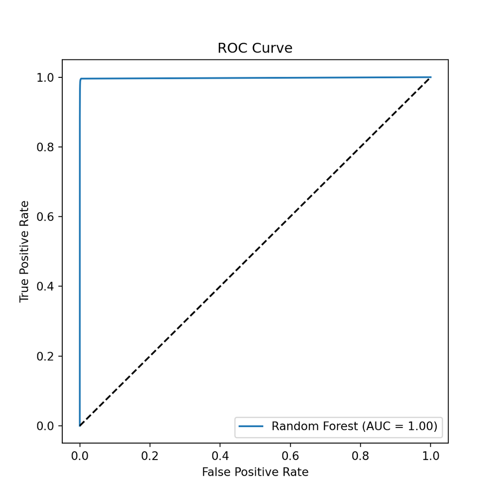

```python
fpr, tpr, _ = roc_curve(y_test, y_prob)
plt.figure(figsize=(6,6))
plt.plot(fpr, tpr, label=f"Random Forest (AUC = {roc_auc:.2f})")
plt.plot([0,1], [0,1], 'k--')
plt.xlabel("False Positive Rate")
plt.ylabel("True Positive Rate")
plt.title("ROC Curve")
plt.legend()
plt.show()
```

## Plotting the Precision-Recall Curve

The relationship between precision and recall is visualized. This is a critical step in evaluating the model’s true performance, especially in imbalanced datasets.

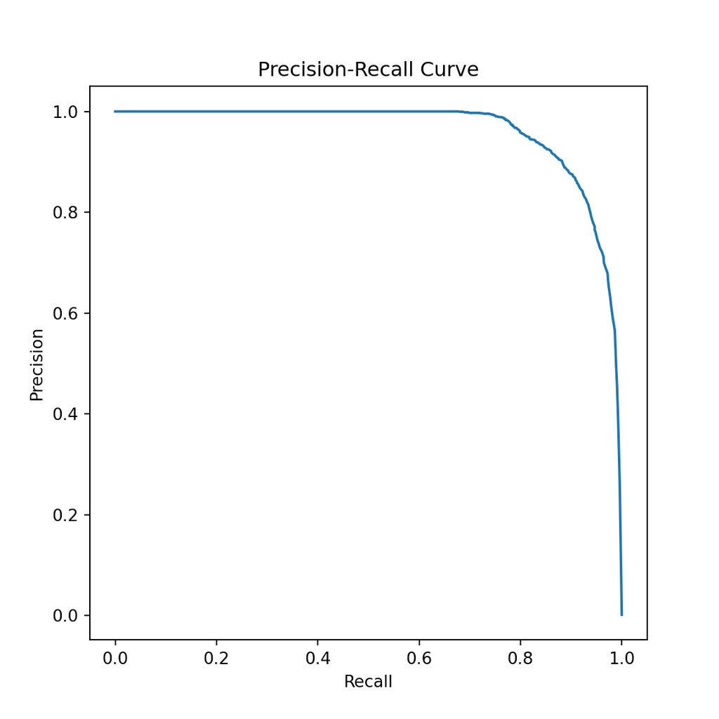

```python
precision, recall, _ = precision_recall_curve(y_test, y_prob)
plt.figure(figsize=(6,6))
plt.plot(recall, precision)
plt.xlabel("Recall")
plt.ylabel("Precision")
plt.title("Precision-Recall Curve")
plt.show()
```

## Filling Missing Values

Missing values are filled with 0.

```python
df = df.fillna(0)
```

## Calculating Feature Importances

```python
importances = rf.feature_importances_
feat_names = X.columns
feat_importance_df = pd.DataFrame({"feature": feat_names, "importance": importances})
feat_importance_df.sort_values(by="importance", ascending=False, inplace=True)

eng_replace= {
    "balanceDiffOrig": "Balance Diff",
    "oldbalanceOrg": "Old Balance",
    "newbalanceOrig": "New Balance",
    "amount": "Amount",
    "balanceDiffDest": "Destination Balance Difference",
    "type_Transfer": "Transfer",
    "type_Ödeme": "Payment",
    "newbalanceDest": "New Destination Balance",
    "type_Nakit Çıkışı": "Cash Out",
    "type_Nakit Girişi": "Cash In"
}


feat_importance_df["feature"] = feat_importance_df["feature"].map(eng_replace)
feat_importance_df_eng_replace = feat_importance_df[["feature", "importance"]].rename(columns={"feature": "Feature", "importance": "Importance"})
top10 = feat_importance_df_eng_replace.head(10)

print(top10)
```

```
##                            Feature  Importance
## 5                     Balance Diff    0.329265
## 1                      Old Balance    0.165233
## 2                      New Balance    0.130133
## 0                           Amount    0.117744
## 6   Destination Balance Difference    0.073868
## 10                        Transfer    0.065961
## 9                              NaN    0.042117
## 4          New Destination Balance    0.035210
## 7                              NaN    0.022224
## 3                              NaN    0.017868
```

## Printing the Top 10 Features

The top 10 most important features are printed on the screen.

```python
print("TOP 10 Features:", feat_importance_df_eng_replace.head(10))
```

```
## TOP 10 Features:                            Feature  Importance
## 5                     Balance Diff    0.329265
## 1                      Old Balance    0.165233
## 2                      New Balance    0.130133
## 0                           Amount    0.117744
## 6   Destination Balance Difference    0.073868
## 10                        Transfer    0.065961
## 9                              NaN    0.042117
## 4          New Destination Balance    0.035210
## 7                              NaN    0.022224
## 3                              NaN    0.017868
```

## Visualization of Feature Importances

For example, in an insurance company, visualizing which factors most affect the fraud risk is critical for managers. If transaction amount or balance difference stand out in the model, these factors should be monitored more closely in risk management.

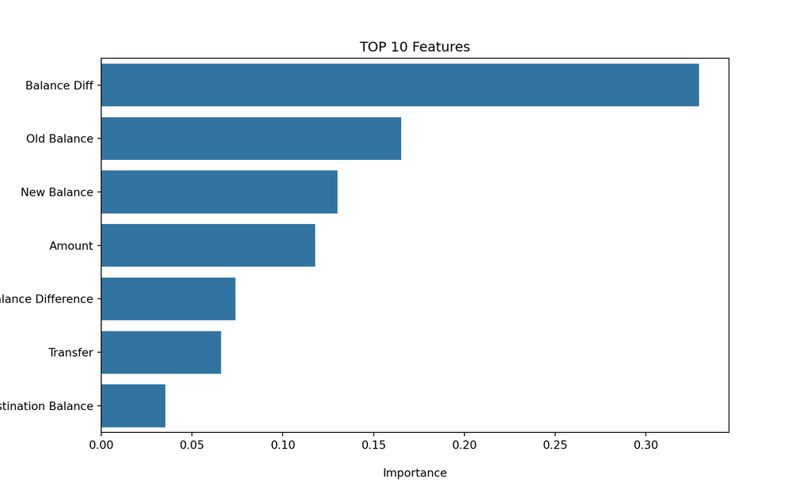

```python
plt.figure(figsize=(10,6))
sns.barplot(x="importance", y="feature", data=feat_importance_df.head(10),)
plt.title("TOP 10 Features")
plt.xlabel("Importance", labelpad=15)
plt.ylabel("Feature")
plt.show()
```

## Conclusion

In this report, analyses were performed on the fraud detection model, and the findings were illustrated using an insurance company scenario. The results highlight the areas where fraud risks are concentrated and demonstrate how successfully the model is able to capture these risks. These efforts provide a strategic foundation to reduce financial losses, enhance customer trust, and strengthen operational processes within the organization.